# Importing and Loading Packages

```r
install.packages("tidyverse", repos = "http://cran.us.r-project.org")
install.packages("ggwordcloud", repos = "http://cran.us.r-project.org")
install.packages("viridis", repos = "http://cran.us.r-project.org")
install.packages("scales", repos = "http://cran.us.r-project.org")

library(tidyverse)
library(ggwordcloud)
library(viridis)
library(scales)
```

# Loading Datasets

```r
#Main Data set
ds_df <- read.csv("ds_salaries.csv")

#Country codes Data set, used for cleaning later
iso <- read.csv("wikipedia-iso-country-codes.csv")
```

# Inspecting the Data

```r
#Inspecting the dataset

colnames(ds_df)  #List of column names
```

```
##  [1] "work_year"          "experience_level"   "employment_type"
##  [4] "job_title"          "salary"             "salary_currency"
##  [7] "salary_in_usd"      "employee_residence" "remote_ratio"
## [10] "company_location"   "company_size"
```

```r
nrow(ds_df)  #How many rows are in the data frame?
```

```
## [1] 3755
```

```r
dim(ds_df)   #Dimensions of the data frame
```

```
## [1] 3755   11
```

```r
head(ds_df)  #Displays the first couple of rows of the data frame
```

```
##   work_year experience_level employment_type                job_title salary
## 1      2023               SE              FT Principal Data Scientist  80000
## 2      2023               MI              CT              ML Engineer  30000
## 3      2023               MI              CT              ML Engineer  25500
## 4      2023               SE              FT           Data Scientist 175000
## 5      2023               SE              FT           Data Scientist 120000
## 6      2023               SE              FT        Applied Scientist 222200
##   salary_currency salary_in_usd employee_residence remote_ratio
## 1             EUR         85847                 ES          100
## 2             USD         30000                 US          100
## 3             USD         25500                 US          100
## 4             USD        175000                 CA          100
## 5             USD        120000                 CA          100
## 6             USD        222200                 US            0
##   company_location company_size
## 1               ES            L
## 2               US            S
## 3               US            S
## 4               CA            M
## 5               CA            M
## 6               US            L
```

```r
str(ds_df)  #Display list of columns and data types
```

```
## 'data.frame':    3755 obs. of  11 variables:
##  $ work_year         : int  2023 2023 2023 2023 2023 2023 2023 2023 2023 2023 ...
##  $ experience_level  : chr  "SE" "MI" "MI" "SE" ...
##  $ employment_type   : chr  "FT" "CT" "CT" "FT" ...
##  $ job_title         : chr  "Principal Data Scientist" "ML Engineer" "ML Engineer" "Data Scientist" ...
##  $ salary            : int  80000 30000 25500 175000 120000 222200 136000 219000 141000 147100 ...
##  $ salary_currency   : chr  "EUR" "USD" "USD" "USD" ...
##  $ salary_in_usd     : int  85847 30000 25500 175000 120000 222200 136000 219000 141000 147100 ...
##  $ employee_residence: chr  "ES" "US" "US" "CA" ...
##  $ remote_ratio      : int  100 100 100 100 100 0 0 0 0 0 ...
##  $ company_location  : chr  "ES" "US" "US" "CA" ...
##  $ company_size      : chr  "L" "S" "S" "M" ...
```

```r
summary(ds_df)  #Statistical summary of data
```

```
##    work_year    experience_level   employment_type     job_title
##  Min.   :2020   Length:3755        Length:3755        Length:3755
##  1st Qu.:2022   Class :character   Class :character   Class :character
##  Median :2022   Mode  :character   Mode  :character   Mode  :character
##  Mean   :2022
##  3rd Qu.:2023
##  Max.   :2023
##      salary         salary_currency    salary_in_usd    employee_residence
##  Min.   :    6000   Length:3755        Min.   :  5132   Length:3755
##  1st Qu.:  100000   Class :character   1st Qu.: 95000   Class :character
##  Median :  138000   Mode  :character   Median :135000   Mode  :character
##  Mean   :  190696                      Mean   :137570
##  3rd Qu.:  180000                      3rd Qu.:175000
##  Max.   :30400000                      Max.   :450000
##   remote_ratio    company_location   company_size
##  Min.   :  0.00   Length:3755        Length:3755
##  1st Qu.:  0.00   Class :character   Class :character
##  Median :  0.00   Mode  :character   Mode  :character
##  Mean   : 46.27
##  3rd Qu.:100.00
##  Max.   :100.00
```

```r
# Checking for any NA values
any(is.na(ds_df))
```

```
## [1] FALSE
```

```r
#Checking for unique values per column
ds_df %>%
  summarise(work_year = n_distinct(work_year), experience_level = n_distinct(experience_level), employment_type = n_distinct(employment_type), job_title = n_distinct(job_title), salary = n_distinct(salary), salary_currency = n_distinct(salary_currency), salary_in_usd = n_distinct(salary_in_usd), employee_residence = n_distinct(employee_residence), remote_ratio = n_distinct(remote_ratio), company_location = n_distinct(company_location), company_size = n_distinct(company_size) )
```

```
##   work_year experience_level employment_type job_title salary salary_currency
## 1         4                4               4        93    815              20
##   salary_in_usd employee_residence remote_ratio company_location company_size
## 1          1035                 78            3               72            3
```

# Cleaning the Data

#### There are a few problems we need to fix:

##### 1. The columns experience_level, employment_type, employee_residence, company_size and company_location contain abbreviations that may not be understood to some, we will rename the data contained in those columns to more descriptive labels.

```r
#Renamed abbreviations for the experience_level column

ds_df$experience_level[ds_df$experience_level == "SE"] <- "Senior-level"
ds_df$experience_level[ds_df$experience_level == "MI"] <- "Indermediate-level"
ds_df$experience_level[ds_df$experience_level == "EN"] <- "Junior/Entry-level"
ds_df$experience_level[ds_df$experience_level == "EX"] <- "Director/Executive-level"

#Renamed abbreviations for the employment_type column

ds_df$employment_type[ds_df$employment_type == "FT"] <- "Full Time"
ds_df$employment_type[ds_df$employment_type == "PT"] <- "Part Time"
ds_df$employment_type[ds_df$employment_type == "CT"] <- "Contract"
ds_df$employment_type[ds_df$employment_type == "FL"] <- "Free Lance"

#Renamed abbreviations for the company_size column

ds_df$company_size[ds_df$company_size == "S"] <- "Small"
ds_df$company_size[ds_df$company_size == "M"] <- "Medium"
ds_df$company_size[ds_df$company_size == "L"] <- "Large"


#Pulling columns from ds_df and iso into vectors that we can iterate from.

employee_residence <- ds_df %>% pull(employee_residence)

Alpha.2.code <- iso %>% pull(Alpha.2.code)

Country_name <- iso %>% pull(English.short.name.lower.case)

index <- 0
new_employee_residence <- c()

#Looping through each item in new_employee_residence

for (item in employee_residence) {

#check where the item exists in Alpha.2.code, then assign the index found in Alpha.2.code to index

    index <- which(Alpha.2.code == item)[1]

#use the index to find the corresponding Country_name, then append that Country_name to new_employee_residence, save to new_employee_residence

    new_employee_residence <- append(new_employee_residence, Country_name[index])
}

# assign new_employee_residence to the employee_residence column

ds_df$employee_residence <- new_employee_residence
```

```r
str(ds_df$experience_level)
```

```
##  chr [1:3755] "Senior-level" "Indermediate-level" "Indermediate-level" ...
```

```r
str(ds_df$employment_type)
```

```
##  chr [1:3755] "Full Time" "Contract" "Contract" "Full Time" "Full Time" ...
```

```r
str(ds_df$employee_residence)
```

```
##  chr [1:3755] "Spain" "United States Of America" "United States Of America" ...
```

```r
str(ds_df$company_size)
```

```
##  chr [1:3755] "Large" "Small" "Small" "Medium" "Medium" "Large" "Large" ...
```

```r
#Pulling company_location from ds_df into a vector that we can iterate from.

company_location <- ds_df %>% pull(company_location)

index <- 0

new_company_location <- c()


#Same For loop as above, but for company_location
for (item in company_location) {
    index <- which(Alpha.2.code == item)[1]
    new_company_location <- append(new_company_location, Country_name[index])
}

ds_df$company_location <- new_company_location

ds_df$employee_residence[ds_df$employee_residence == "United States Of America"] <- "USA"
ds_df$employee_residence[ds_df$employee_residence == "United Kingdom"] <- "UK"

ds_df$company_location[ds_df$company_location == "United States Of America"] <- "USA"
ds_df$company_location[ds_df$company_location == "United Kingdom"] <- "UK"
```

```r
str(ds_df$company_location)
```

```
##  chr [1:3755] "Spain" "USA" "USA" "Canada" "Canada" "USA" "USA" "Canada" ...
```

##### 2. We do not need the salary or salary_currency columns for our analysis.

```r
ds_df <- ds_df %>%
  select(-c(salary, salary_currency))

str(ds_df)
```

```
## 'data.frame':    3755 obs. of  9 variables:
##  $ work_year         : int  2023 2023 2023 2023 2023 2023 2023 2023 2023 2023 ...
##  $ experience_level  : chr  "Senior-level" "Indermediate-level" "Indermediate-level" "Senior-level" ...
##  $ employment_type   : chr  "Full Time" "Contract" "Contract" "Full Time" ...
##  $ job_title         : chr  "Principal Data Scientist" "ML Engineer" "ML Engineer" "Data Scientist" ...
##  $ salary_in_usd     : int  85847 30000 25500 175000 120000 222200 136000 219000 141000 147100 ...
##  $ employee_residence: chr  "Spain" "USA" "USA" "Canada" ...
##  $ remote_ratio      : int  100 100 100 100 100 0 0 0 0 0 ...
##  $ company_location  : chr  "Spain" "USA" "USA" "Canada" ...
##  $ company_size      : chr  "Large" "Small" "Small" "Medium" ...
```

##### 3. Since remote_ratio contains ratios they all should have % at the end.

```r
#Add a % at the end of every element in remote_ratio
remote_ratio <- ds_df %>% pull(remote_ratio)
new_remote_ratio <- c()
for(item in remote_ratio) {
    new_remote_ratio <- append(new_remote_ratio, paste(item, "%", sep = ""))
}

ds_df$remote_ratio <- new_remote_ratio
```

```r
str(ds_df$remote_ratio)
```

```
##  chr [1:3755] "100%" "100%" "100%" "100%" "100%" "0%" "0%" "0%" "0%" "0%" ...
```

# Analysis

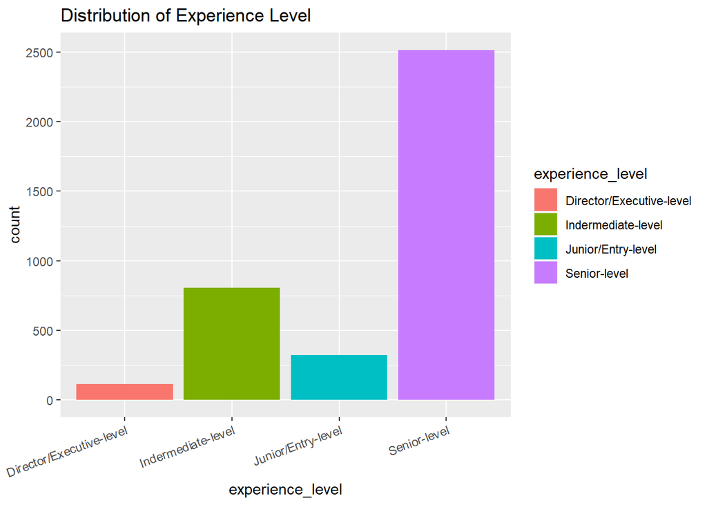

```r
# What's the distribution of experience_level?
experience_level <- data.frame(experience_level = ds_df$experience_level)

ggplot(data = experience_level) +
     geom_bar(mapping = aes(x = experience_level, fill = experience_level))+
     theme(axis.text.x = element_text(angle =20, hjust = 1))+
     labs(title = "Distribution of Experience Level")
```

Most people with data science related jobs are Senior level.

```r
query <- ds_df %>%
  select(job_title, experience_level) %>%
  group_by(job_title, experience_level) %>%
  summarise("Count" = n()) %>%
  arrange(desc(Count)) %>%
  filter(job_title == "Data Engineer" |job_title == "Data Scientist" |job_title == "Data Analyst" |job_title == "Machine Learning Engineer" |job_title == "Analytics Engineer" |job_title == "Data Architect" |job_title == "Research Scientist" |job_title == "Applied Scientist" |job_title == "Data Science Manager" |job_title == "Research Engineer")
```

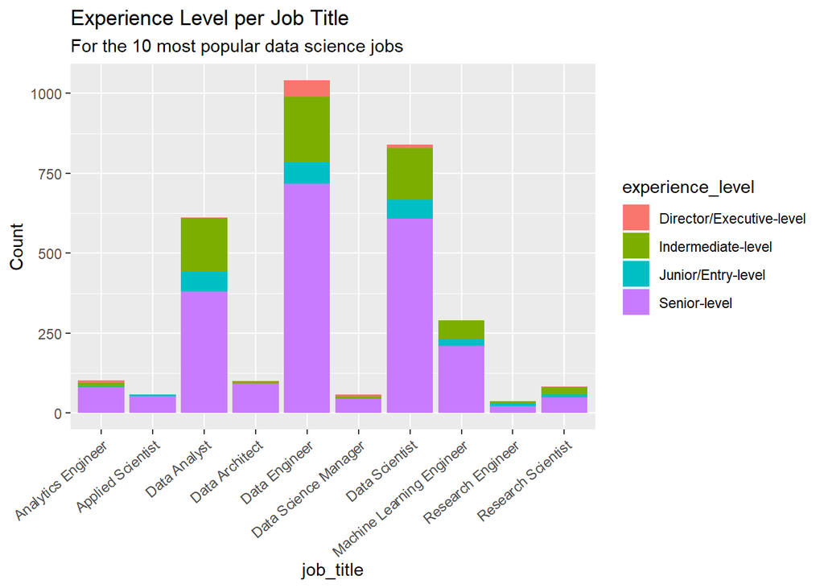

```r
ggplot(query, aes(x = job_title, y = Count, fill = experience_level)) +
  geom_col()+
  theme(axis.text.x = element_text(angle =40, hjust = 1))+
  labs(title = "Experience Level per Job Title", subtitle = "For the 10 most popular data science jobs")
```

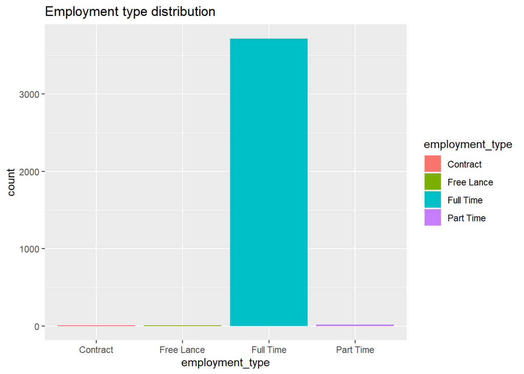

```r
employment_type <- data.frame(employment_type = ds_df$employment_type)

ggplot(data = employment_type) +
    geom_bar(mapping = aes(x = employment_type, fill = employment_type))+
    labs(title = "Employment type distribution")
```

Virtually all employees are full time.

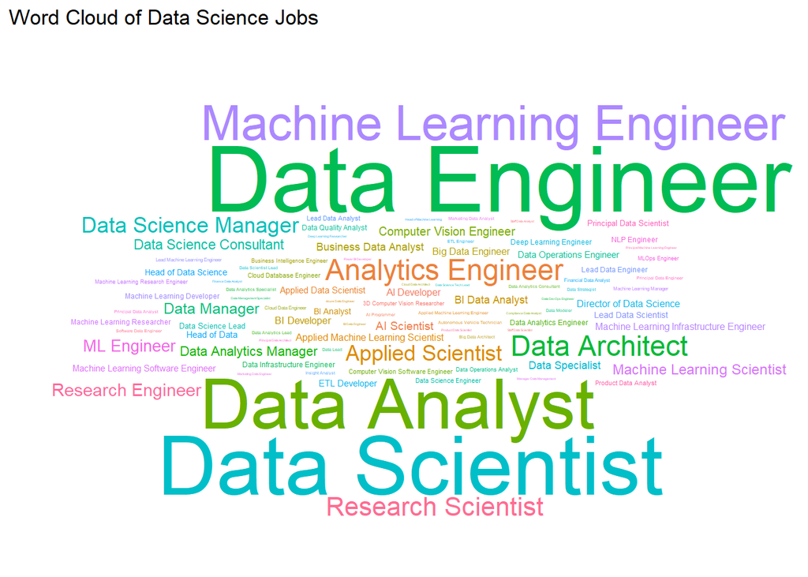

```r
job_title <- data.frame(table(job_title = ds_df$job_title))

ggplot(data = job_title, aes(label = job_title, size = Freq, color = job_title)) +
     geom_text_wordcloud(rm_outside = TRUE) +
     scale_size_area(max_size = 20) +
     theme_minimal()+
     labs(title = "Word Cloud of Data Science Jobs")
```

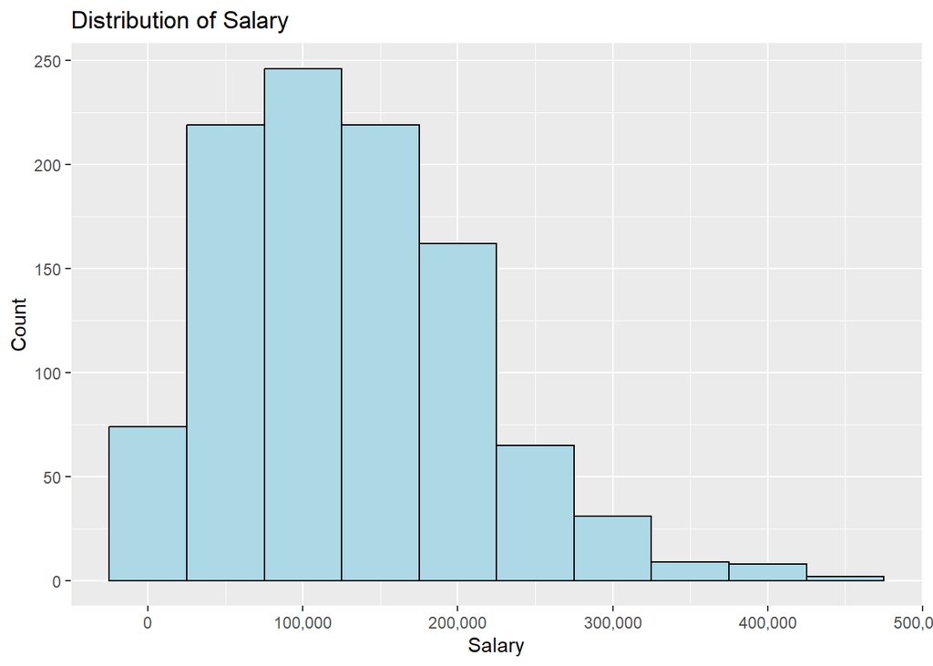

```r
salary <- data.frame(table(ds_df$salary_in_usd))

salary$Var1 <- as.numeric(as.character(salary$Var1))

ggplot(salary, aes(x = Var1)) +
     geom_histogram(binwidth = 50000, fill="lightblue", color="black")+
     scale_x_continuous(labels = scales::comma)+
     labs(title = "Distribution of Salary", x = "Salary", y = "Count")
```

```r
print(summary(salary))
```

```
##       Var1             Freq
##  Min.   :  5132   Min.   : 1.000
##  1st Qu.: 67862   1st Qu.: 1.000
##  Median :121600   Median : 1.000
##  Mean   :130008   Mean   : 3.628
##  3rd Qu.:179638   3rd Qu.: 2.000
##  Max.   :450000   Max.   :99.000
```

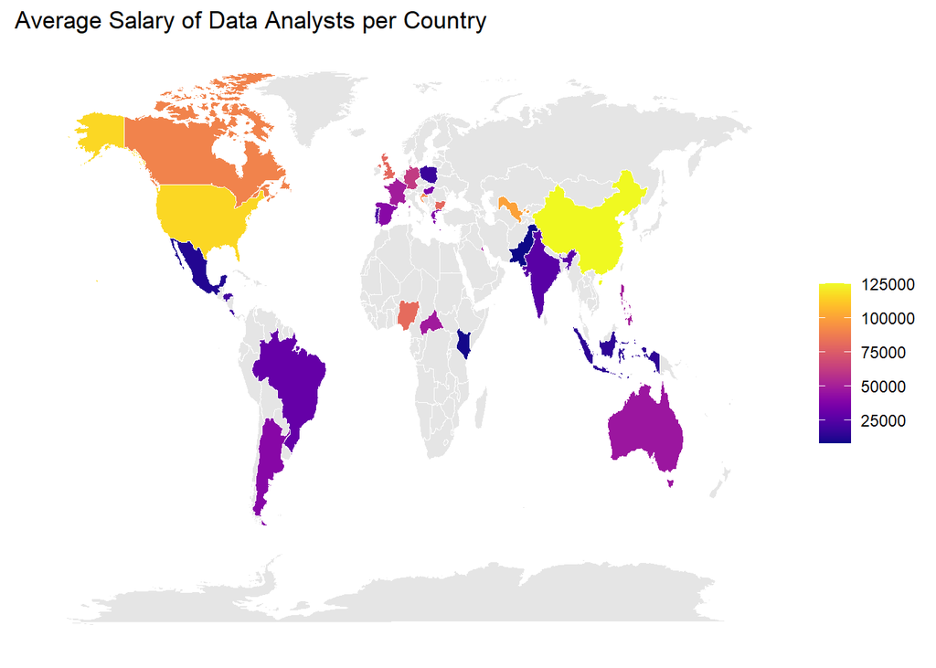

```r
 data <- ds_df %>%
     select(job_title, salary_in_usd,
     employee_residence) %>%
     filter(job_title == "Data Analyst" | job_title == "BI Analyst" | job_title == "BI Data Analyst" | job_title == "Business Data Analyst" | job_title == "Data Analytics Specialist" | job_title == "Data Operations Analyst" | job_title == "Data Quality Analyst" | job_title == "Finance Data Analyst" | job_title == "Financial Data Analyst" | job_title == "Insight Analyst" | job_title == "Lead Data Analyst" | job_title == "Marketing Data Analyst" | job_title == "Principal Data Analyst" | job_title == "Product Data Analyst" | job_title == "Staff Data Analyst")%>%
     group_by(employee_residence) %>%
     summarise(mean = mean(salary_in_usd))


world <- map_data("world")

world %>%
     merge(data, by.x = "region", by.y = "employee_residence", all.x = T) %>%
     arrange(group, order) %>%
     ggplot(aes(x = long, y = lat, group = group, fill = mean))+
     geom_polygon(color = "white", linewidth = 0.2) +
     scale_fill_viridis("", na.value = "gray90", option = "C") +
     theme_minimal() +
     theme(axis.text = element_blank(),
           axis.title = element_blank(),


           panel.grid = element_blank())+
     labs(title = "Average Salary of Data Analysts per Country")
```

Data Analysis in China make the most, followed by data analysts in the US.

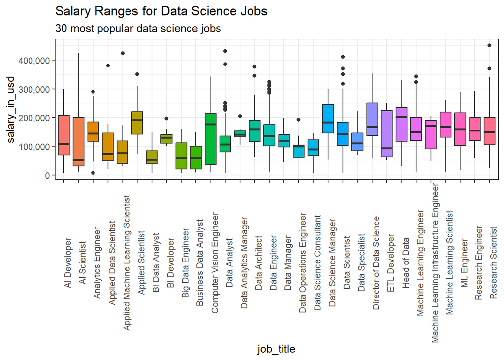

```r
ds_df$salary_in_usd <- as.numeric(ds_df$salary_in_usd)

temp <- data.frame(table(ds_df$job_title))

temp <- temp %>%
  arrange(desc(Freq)) %>%
  head(n = 70)

data <- ds_df %>%
  select(job_title, salary_in_usd) %>%
  filter(job_title == "Data Engineer" | job_title == "Data Scientist" | job_title == "Data Analyst" | job_title == "Machine Learning Engineer" | job_title == "Analytics Engineer" | job_title == "Data Architect" | job_title == "Research Scientist" | job_title == "Applied Scientist" | job_title == "Data Science Manager" | job_title == "Research Engineer" | job_title == "ML Engineer" | job_title == "Data Manager" | job_title == "Machine Learning Scientist" | job_title == "Data Science Consultant" | job_title == "Data Analytics Manager" | job_title == "Computer Vision Engineer" | job_title == "AI Scientist" | job_title == "BI Data Analyst" | job_title == "Business Data Analyst" | job_title == "Data Specialist" | job_title == "BI Developer" | job_title == "Applied Machine Learning Scientist" | job_title == "AI Developer" | job_title == "Big Data Engineer" | job_title == "Director of Data Science" | job_title == "Machine Learning Infrastructure Engineer" | job_title == "Applied Data Scientist" | job_title == "Data Operations Engineer" | job_title == "ETL Developer" | job_title == "Head of Data")

data %>%
     ggplot(aes(job_title, salary_in_usd, fill = job_title))+
     geom_boxplot()+
     theme_bw()+
     theme(axis.text.x = element_text(angle = 90), legend.position = "none")+
     scale_y_continuous(labels = comma)+
     labs(title = "Salary Ranges for Data Science Jobs", subtitle = "30 most popular data science jobs")
```

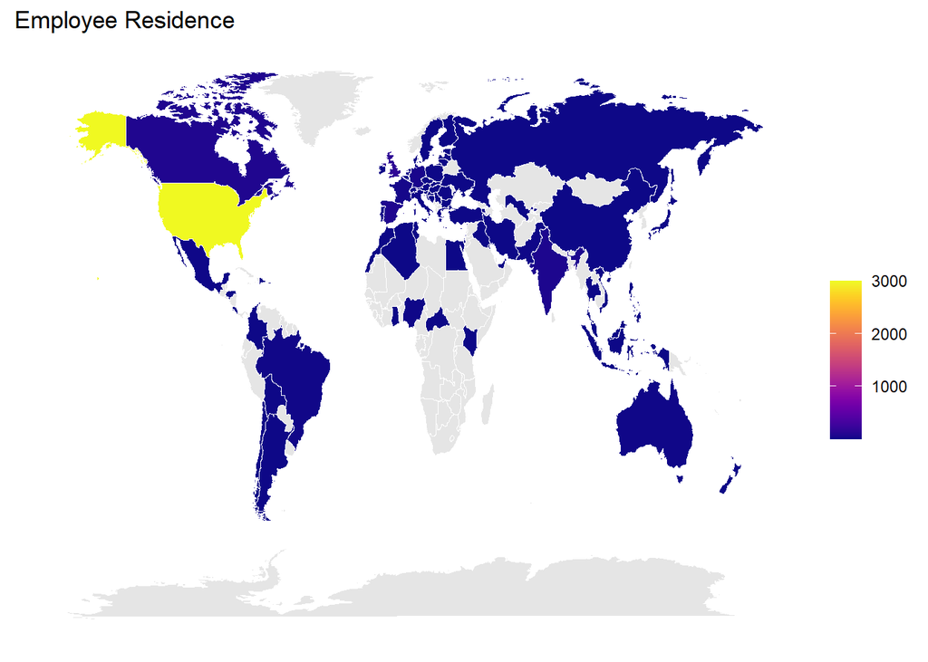

```r
data <- data.frame(table(ds_df$employee_residence))

world <- map_data("world")

world %>%
     merge(data, by.x = "region", by.y = "Var1", all.x = T) %>%
     arrange(group, order) %>%
     ggplot(aes(x = long, y = lat, group = group, fill = Freq))+
     geom_polygon(color = "white", linewidth = 0.2) +
     scale_fill_viridis("", na.value = "gray90", option = "C") +
     theme_minimal() +
     theme(axis.text = element_blank(),
           axis.title = element_blank(),
           panel.grid = element_blank())+
     labs(title = "Employee Residence")
```

Virtually all employees in the data live in the US.

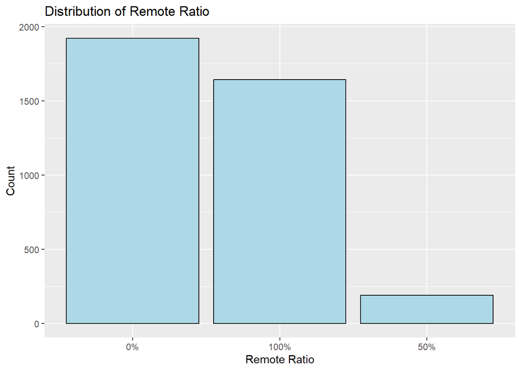

```r
remote_ratio <- data.frame(table(ds_df$remote_ratio))

remote_ratio %>%
     ggplot(aes(x = Var1, y = Freq))+
     geom_col(fill = "lightblue", color = "black")+
     xlab("Remote Ratio") +
     ylab("Count")+
     labs(title = "Distribution of Remote Ratio")
```

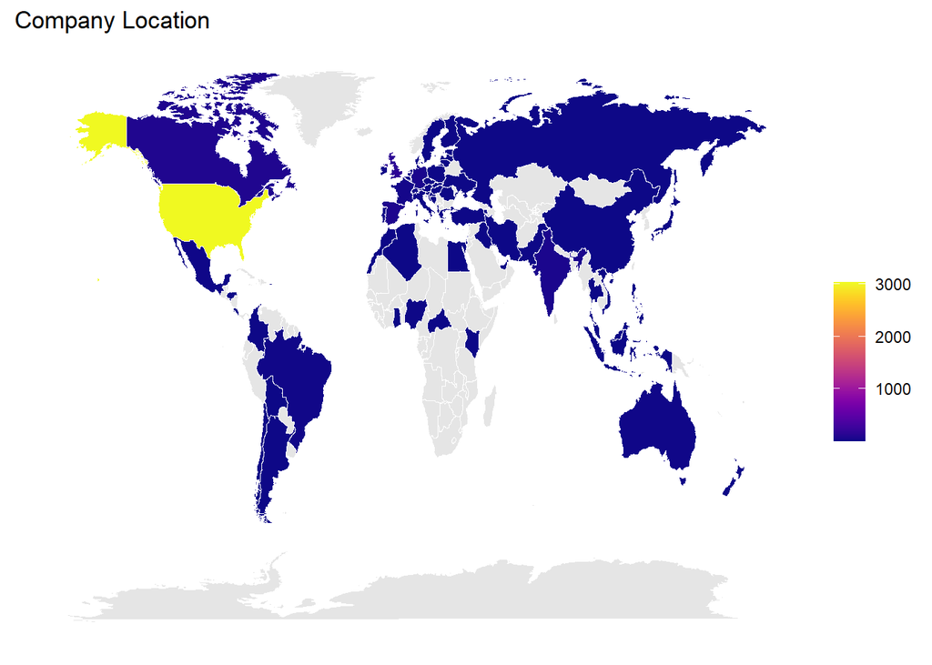

```r
data <- data.frame(table(ds_df$company_location))

world <- map_data("world")

world %>%
     merge(data, by.x = "region", by.y = "Var1", all.x = T) %>%
     arrange(group, order) %>%
     ggplot(aes(x = long, y = lat, group = group, fill = Freq))+
     geom_polygon(color = "white", linewidth = 0.2) +
     scale_fill_viridis("", na.value = "gray90", option = "C") +
     theme_minimal() +
     theme(axis.text = element_blank(),
           axis.title = element_blank(),
           panel.grid = element_blank())+
     ggtitle("Company Location")
```

Virtually all data science companies are located in the US.

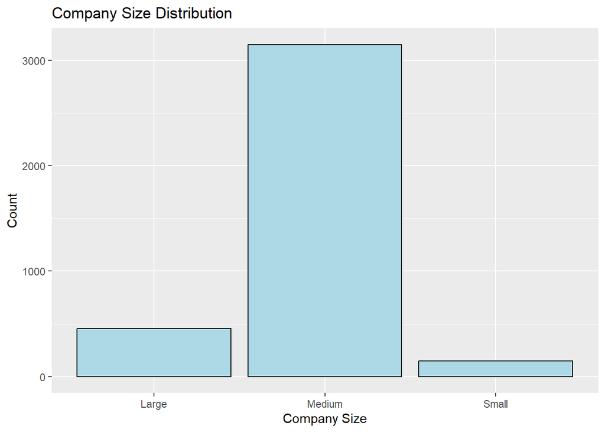

```r
company_size <- data.frame(table(ds_df$company_size))

 company_size %>%
     ggplot(aes(x = Var1, y = Freq))+
     geom_col(fill = "lightblue", color = "black")+
     labs(title = "Company Size Distribution", x = "Company Size", y = "Count")
```

Most Companies are medium sized (50-250 employees).

# Conclusions

In conclusion, our analysis provides a valuable snapshot of the current state and trends of data science salaries in the US, which can help data scientists and employers make informed decisions and plan their careers.